# Final Project

Willie, Lauren, Leo

Sunday, May 10, 2015

Data used:

WHO Data: http://apps.who.int/gho/data/node.main.GISAH?lang=en

USA Department of Transportation Statistics: http://www.rita.dot.gov/bts/sites/rita.dot.gov.bts/files/publications/by_the_numbers/drunk_driving/index.html

Reformatting the Data and visualizing plots of alcohol abstainers

```r
source("../01 Data/abstainers.R", echo = TRUE)
```

```
##
## > require("jsonlite")
```

```
##
## > library("RCurl")
```

```
##
## > require(dplyr)
```

```
##
## > require("ggplot2")
```

```
##
## > library(extrafont)
```

```
## Registering fonts with R
```

```
##
## > library("reshape2")
##
## > setwd("C:/Users/willieman/Desktop/Skool/College Homework/_Senior Year/Spring 2015/CS 329e/DataVisualization/DV_FinalProject/0 Doc")
##
## > file_path <- "Abstainers-past-12-months - Copy.csv"
##
## > df <- read.csv(file_path, stringsAsFactors = FALSE)
##
## > names(df) <- gsub("\\.+", "_", names(df))
##
## > str(df)
## 'data.frame':    193 obs. of  5 variables:
##  $ Country  : chr  "Afghanistan" "Albania" "Algeria" "Andorra" ...
##  $ Year     : int  2010 2010 2010 2010 2010 2010 2010 2010 2010 2010 ...
##  $ Male     : num  95.1 38.7 86.5 26.6 52 26.9 30 16 12 19 ...
##  $ Female   : num  97.6 53.6 95 36.7 76.4 39.6 51.7 56 19.9 26 ...
##  $ Bothsexes: num  96.3 46.2 90.7 31.7 64.4 33.4 41.2 36 16 22.6 ...
##
## > measures <- c("Year", "Male", "Female", "Bothsexes")
##
## > for (n in names(df)) {
## +     df[n] <- data.frame(lapply(df[n], gsub, pattern = "[^ -~]",
## +         replacement = ""))
## + }
##
## > dimensions <- setdiff(names(df), measures)
##
## > for (d in dimensions) {
## +     df[d] <- data.frame(lapply(df[d], gsub, pattern = "[\"']",
## +         replacement = ""))
## +     df[d] <- data.frame(lap ..." ... [TRUNCATED]
##
## > for (m in measures) {
## +     df[m] <- data.frame(lapply(df[m], gsub, pattern = "[^--.0-9]",
## +         replacement = ""))
## + }
##
## > write.csv(df, paste(gsub(".csv", "", file_path), ".reformatted.csv",
## +     sep = ""), row.names = FALSE, na = "")
```

[output cut: 59 more lines]

```
##                COUNTRY variable value
## 1          Afghanistan   MALE.x    90
## 2              Albania   MALE.x    18
## 3              Algeria   MALE.x    75
## 4              Andorra   MALE.x     8
## 5               Angola   MALE.x    38
## 6  Antigua and Barbuda   MALE.x     8
## 7            Argentina   MALE.x    12
## 8              Armenia   MALE.x     8
## 9            Australia   MALE.x     6
## 10             Austria   MALE.x    14
## ..                 ...      ...   ...
##
## > ggplot(data = abstainers) + geom_histogram(aes(x = MALE.x),
## +     binwidth = 5) + xlab("Male Abstainers Life Time") + ylab("Count")
```

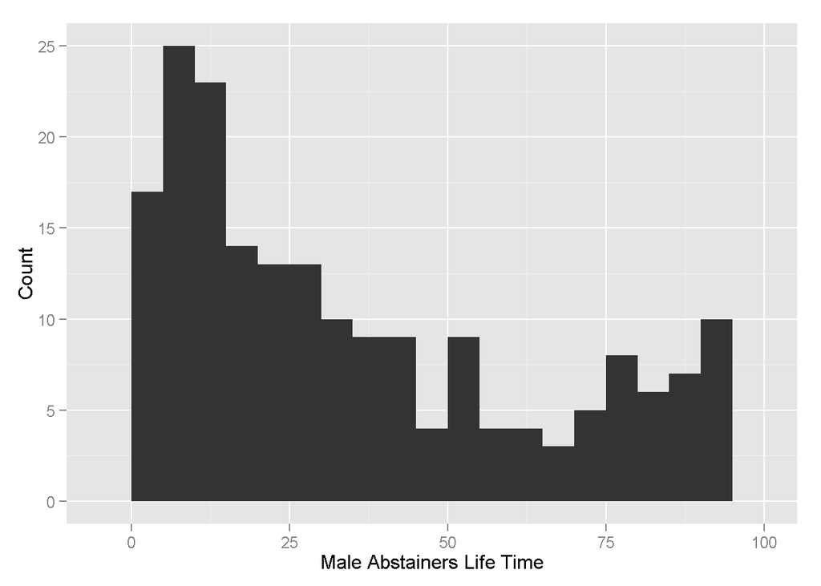

```
##
## > ggplot(data = abstainers) + geom_histogram(aes(x = MALE.y),
## +     binwidth = 5) + xlab("Male Abstainers 12 Months") + ylab("Count")
```

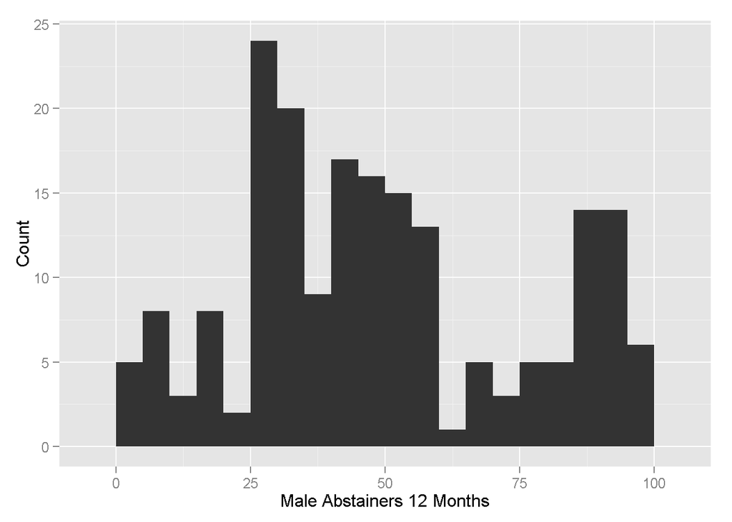

```
##
## > ggplot(data = abstainers) + geom_histogram(aes(x = FEMALE.x),
## +     binwidth = 5) + xlab("Female Abstainers Life Time") + ylab("Count")
```

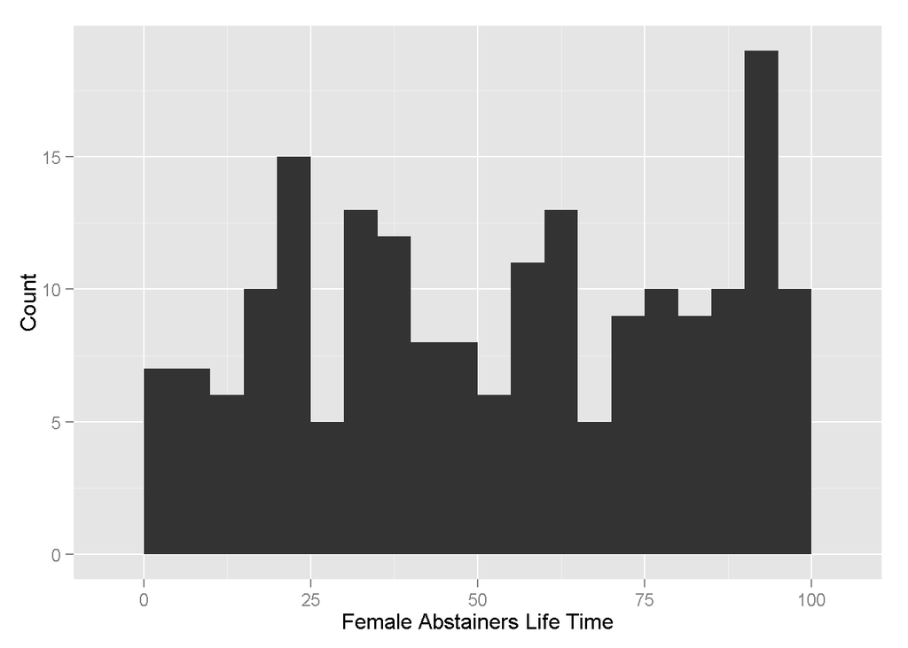

```
##
## > ggplot(data = abstainers) + geom_histogram(aes(x = FEMALE.y),
## +     binwidth = 5) + xlab("Female Abstainers 12 Months") + ylab("Count")
```

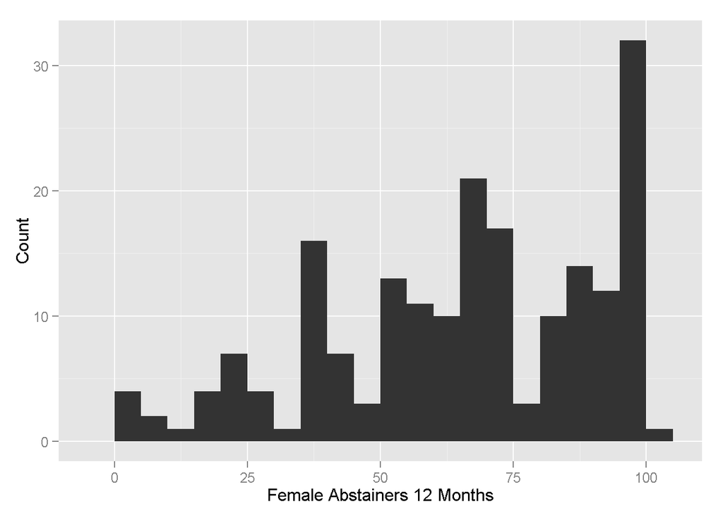

```
##
## > ggplot(data = abstainers) + geom_histogram(aes(x = BOTHSEXES.x,
## +     binwidth = 5)) + xlab("Both Genders Abstainers Life Time") +
## +     ylab("Cou ..." ... [TRUNCATED]
```

```
## stat_bin: binwidth defaulted to range/30. Use 'binwidth = x' to adjust this.
```

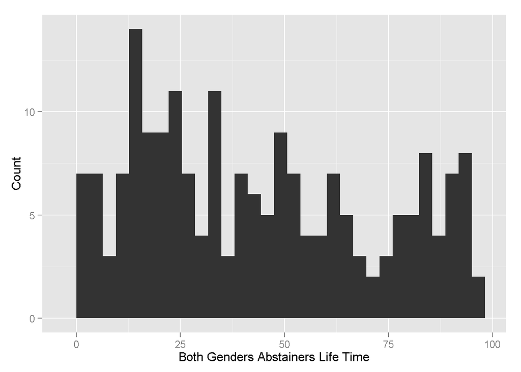

```
##
## > ggplot(data = abstainers) + geom_histogram(aes(x = BOTHSEXES.y,
## +     binwidth = 5)) + xlab("Both Genders Abstainers 12 Months") +
## +     ylab("Cou ..." ... [TRUNCATED]
```

```
## stat_bin: binwidth defaulted to range/30. Use 'binwidth = x' to adjust this.
```

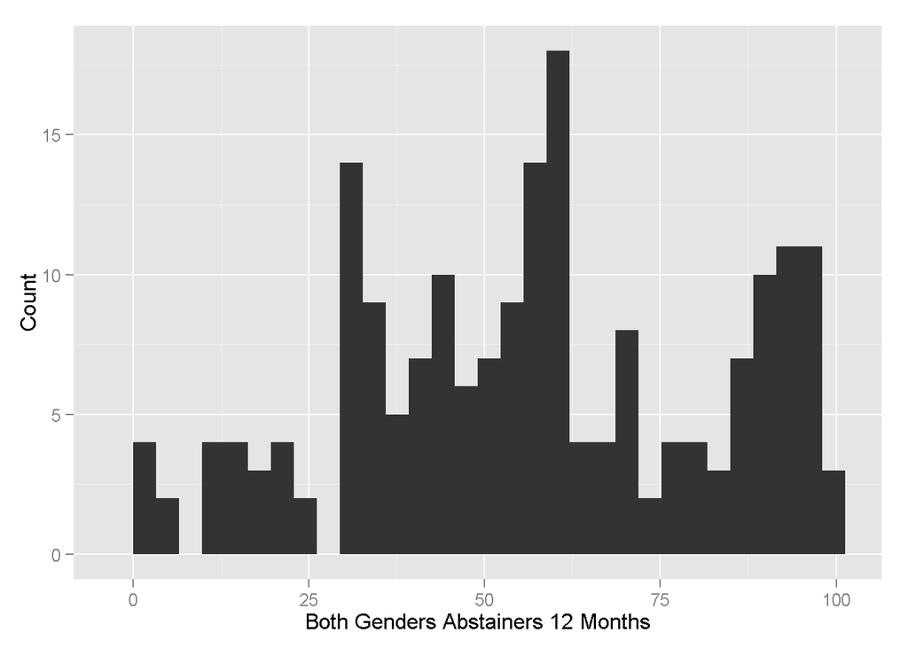

Reformatting the Data and visualizing plots of alcohol consumption by type

```r
source("../01 Data/Consumptionbyalcohol.R", echo = TRUE)
```

```
##
## > require("jsonlite")
##
## > library("RCurl")
##
## > require(dplyr)
##
## > require("ggplot2")
##
## > library(extrafont)
##
## > library("reshape2")
##
## > setwd("C:/Users/willieman/Desktop/Skool/College Homework/_Senior Year/Spring 2015/CS 329e/DataVisualization/DV_FinalProject/0 Doc")
##
## > file_path <- "Consumption of pure alcohol  - Copy.csv"
##
## > df <- read.csv(file_path, stringsAsFactors = FALSE)
##
## > names(df) <- gsub("\\.+", "_", names(df))
##
## > str(df)
## 'data.frame':    195 obs. of  6 variables:
##  $ Country                  : chr  "Afghanistan" "Albania" "Algeria" "Andorra" ...
##  $ Year                     : int  2010 2010 2010 2010 2010 2010 2010 2010 2010 2010 ...
##  $ Beer                     : chr  "No data" "31.8" "62.6" "34.6" ...
##  $ Wine                     : chr  "No data" "19.8" "35.5" "45.3" ...
##  $ Spirits                  : chr  "No data" "48.4" "0" "20.1" ...
##  $ Other_alcoholic_beverages: chr  "No data" "0" "2" "0" ...
##
## > measures <- c("Year", "Beer", "Wine", "Spirits", "Other_alcoholic_beverages")
##
## > for (n in names(df)) {
## +     df[n] <- data.frame(lapply(df[n], gsub, pattern = "[^ -~]",
## +         replacement = ""))
## + }
##
## > dimensions <- setdiff(names(df), measures)
##
## > for (d in dimensions) {
```

[output cut: 33 more lines]

```
##  Beer number(38,4),
##  Wine number(38,4),
##  Spirits number(38,4),
##  Other_alcoholic_beverages number(38,4)
##  );
## > CONSUMPTION_OF_PURE_ALCOHOL <- data.frame(fromJSON(getURL(URLencode("129.152.144.84:5001/rest/native/?query=\"select * from CONSUMPTION_OF_PURE_ALCO .... [TRUNCATED]
##
## > names(CONSUMPTION_OF_PURE_ALCOHOL)
## [1] "COUNTRY"                   "YEAR"
## [3] "BEER"                      "WINE"
## [5] "SPIRITS"                   "OTHER_ALCOHOLIC_BEVERAGES"
##
## > mdf_consumption <- melt(CONSUMPTION_OF_PURE_ALCOHOL,
## +     id.vars = "COUNTRY", measure.vars = c("BEER", "WINE", "SPIRITS",
## +         "OTHER_ALCOH ..." ... [TRUNCATED]
```

```
##
## > ggplot(mdf_consumption, aes(x = COUNTRY, y = value,
## +     fill = variable)) + geom_bar(stat = "identity")
```

[figure not shown]

Reformatting the Data and visualizing plots of economic costs

```r
source("../01 Data/Costs.R", echo = TRUE)
```

```
##
## > require("jsonlite")
##
## > library("RCurl")
##
## > require(dplyr)
##
## > require("ggplot2")
##
## > library(extrafont)
##
## > setwd("C:/Users/willieman/Desktop/Skool/College Homework/_Senior Year/Spring 2015/CS 329e/DataVisualization/DV_FinalProject/0 Doc")
##
## > file_path <- "Cost2.csv"
##
## > df <- read.csv(file_path, stringsAsFactors = FALSE)
##
## > names(df) <- gsub("\\.+", "_", names(df))
##
## > str(df)
## 'data.frame':    11 obs. of  7 variables:
##  $ Country            : chr  "Argentina" "Australia" "Canada" "Chile" ...
##  $ Year               : int  2007 1998 2002 1998 1997 2007 1996 2002 2002 2003 ...
##  $ Total_costs        : num  948 5228 13958 2970 25347 ...
##  $ Direct_law_costs   : num  NA 809 2946.4 8.3 80.7 ...
##  $ Direct_health_costs: num  177 212 3171 114 4046 ...
##  $ Direct_other_costs : num  295 2300 1006 21 8581 ...
##  $ Indirect_costs     : num  476 1906 6834 2827 12640 ...
##
## > measures <- c("Year", "Total_costs", "Direct_law_costs",
## +     "Direct_health_costs", "Indirect_costs")
##
## > for (n in names(df)) {
## +     df[n] <- data.frame(lapply(df[n], gsub, pattern = "[^ -~]",
## +         replacement = ""))
## + }
##
## > dimensions <- setdiff(names(df), measures)
##
## > for (d in dimensions) {
```

[output cut: 35 more lines]

```
##  Direct_law_costs number(38,4),
##  Direct_health_costs number(38,4),
##  Indirect_costs number(38,4)
##  );
## > Costs <- data.frame(fromJSON(getURL(URLencode("129.152.144.84:5001/rest/native/?query=\"select * from cost\""),
## +     httpheader = c(DB = "jdbc:ora ..." ... [TRUNCATED]
##
## > names(Costs)
## [1] "COUNTRY"             "DIRECT_OTHER_COSTS"  "YEAR"
## [4] "TOTAL_COSTS"         "DIRECT_LAW_COSTS"    "DIRECT_HEALTH_COSTS"
## [7] "INDIRECT_COSTS"
##
## > ggplot(Costs, aes(x = COUNTRY, y = TOTAL_COSTS)) +
## +     geom_bar(stat = "identity") + theme(plot.title = element_text(size = 20,
## +     face = "bo ..." ... [TRUNCATED]
```

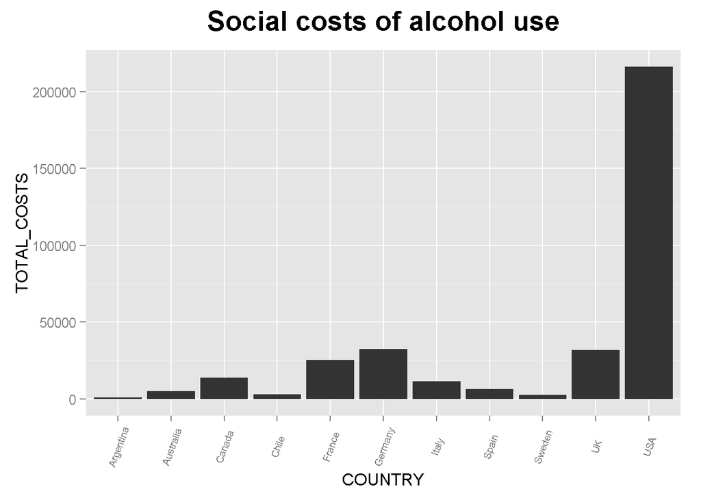

```
##
## > names(Costs)
## [1] "COUNTRY"             "DIRECT_OTHER_COSTS"  "YEAR"
## [4] "TOTAL_COSTS"         "DIRECT_LAW_COSTS"    "DIRECT_HEALTH_COSTS"
## [7] "INDIRECT_COSTS"
##
## > mdf_Costs <- melt(Costs, id.vars = "COUNTRY", measure.vars = c("DIRECT_LAW_COSTS",
## +     "DIRECT_HEALTH_COSTS", "DIRECT_OTHER_COSTS", "INDIRECT_COS ..." ... [TRUNCATED]
##
## > ggplot(mdf_Costs, aes(x = COUNTRY, y = value, fill = variable)) +
## +     geom_bar(stat = "identity") + theme(axis.text.x = element_text(angle = 50,  .... [TRUNCATED]
```

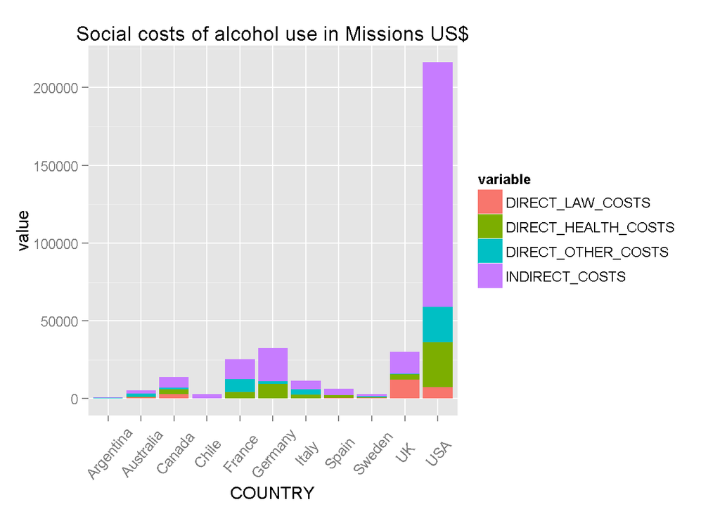

```r
source("../01 Data/Drinking policies.R", echo = TRUE)
```

```
##
## > require("jsonlite")
##
## > library("RCurl")
##
## > require(dplyr)
##
## > require("ggplot2")
##
## > library(extrafont)
##
## > setwd("C:/Users/willieman/Desktop/Skool/College Homework/_Senior Year/Spring 2015/CS 329e/DataVisualization/DV_FinalProject/0 Doc")
##
## > df <- read.csv(file_path, stringsAsFactors = FALSE)
##
## > names(df) <- gsub("\\.+", "_", names(df))
##
## > str(df)
## 'data.frame':    11 obs. of  7 variables:
##  $ Country            : chr  "Argentina" "Australia" "Canada" "Chile" ...
##  $ Year               : int  2007 1998 2002 1998 1997 2007 1996 2002 2002 2003 ...
##  $ Total_costs        : num  948 5228 13958 2970 25347 ...
##  $ Direct_law_costs   : num  NA 809 2946.4 8.3 80.7 ...
##  $ Direct_health_costs: num  177 212 3171 114 4046 ...
##  $ Direct_other_costs : num  295 2300 1006 21 8581 ...
##  $ Indirect_costs     : num  476 1906 6834 2827 12640 ...
##
## > measures <- c("Year")
##
## > for (n in names(df)) {
## +     df[n] <- data.frame(lapply(df[n], gsub, pattern = "[^ -~]",
## +         replacement = ""))
## + }
##
## > dimensions <- setdiff(names(df), measures)
##
## > for (d in dimensions) {
## +     df[d] <- data.frame(lapply(df[d], gsub, pattern = "[\"']",
## +         replacement = ""))
## +     df[d] <- data.frame(lap ..." ... [TRUNCATED]
```

[output cut: 21 more lines]

```
## +     else sql <- paste(sql, p .... [TRUNCATED]
##
## > sql <- paste(sql, ");")
##
## > cat(sql)
## CREATE TABLE Cost2 (
## -- Change table_name to the table name you want.
##  Country varchar2(4000),
##  Total_costs varchar2(4000),
##  Direct_law_costs varchar2(4000),
##  Direct_health_costs varchar2(4000),
##  Direct_other_costs varchar2(4000),
##  Indirect_costs varchar2(4000),
##  Year number(38,4)
##  );
```

Reformatting and Visualizing Drunk Driving Statistics

```r
source("../01 Data/Drunk_driving.R", echo = TRUE)
```

```
##
## > require("jsonlite")
##
## > library("RCurl")
##
## > require(dplyr)
##
## > require("ggplot2")
##
## > library(extrafont)
##
## > library("reshape2")
##
## > setwd("C:/Users/willieman/Desktop/Skool/College Homework/_Senior Year/Spring 2015/CS 329e/DataVisualization/DV_FinalProject/0 Doc")
##
## > file_path <- "figure_03_2.csv"
##
## > df <- read.csv(file_path, stringsAsFactors = FALSE)
##
## > names(df) <- gsub("\\.+", "_", names(df))
##
## > str(df)
## 'data.frame':    11 obs. of  5 variables:
##  $ Year                  : int  2001 2002 2003 2004 2005 2006 2007 2008 2009 2010 ...
##  $ Total_Fatalities      : int  681 750 703 676 697 710 685 709 736 672 ...
##  $ Alcohol_Use_Fatalities: int  125 145 129 124 157 148 157 153 165 154 ...
##  $ Without_Alcohol_Use   : int  556 605 574 552 540 562 528 556 571 518 ...
##  $ Percentage            : num  18.4 19.3 18.3 18.3 22.5 20.8 22.9 21.6 22.4 22.9 ...
##
## > measures <- c("Year", "Total_Fatalities", "Alcohol_Use_Fatalities",
## +     "Without_Alcohol_Use", "Percentage")
##
## > for (n in names(df)) {
## +     df[n] <- data.frame(lapply(df[n], gsub, pattern = "[^ -~]",
## +         replacement = ""))
## + }
##
## > dimensions <- setdiff(names(df), measures)
##
## > for (d in dimensions) {
```

[output cut: 33 more lines]

```
##  Alcohol_Use_Fatalities number(38,4),
##  Without_Alcohol_Use number(38,4),
##  Percentage number(38,4)
##  );
## > figure_01_2 <- data.frame(fromJSON(getURL(URLencode("129.152.144.84:5001/rest/native/?query=\"select * from figure_01_2\""),
## +     httpheader = c(D .... [TRUNCATED]
##
## > figure_02_2 <- data.frame(fromJSON(getURL(URLencode("129.152.144.84:5001/rest/native/?query=\"select * from figure_02_2\""),
## +     httpheader = c(D .... [TRUNCATED]
##
## > figure_03_2 <- data.frame(fromJSON(getURL(URLencode("129.152.144.84:5001/rest/native/?query=\"select * from figure_03_2\""),
## +     httpheader = c(D .... [TRUNCATED]
##
## > ggplot(figure_01_2, aes(x = YEAR, y = TOTAL_FATALITIES)) +
## +     geom_line() + ggtitle("Total US Fatalities vs Year")
```

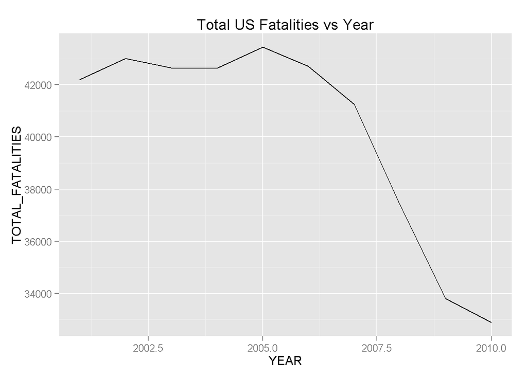

```
##
## > ggplot(figure_01_2, aes(x = YEAR, y = ALCOHOL_RELATED_FATALITIES)) +
## +     geom_line() + ggtitle("Total Alcohol Related Fatalities vs Year")
```

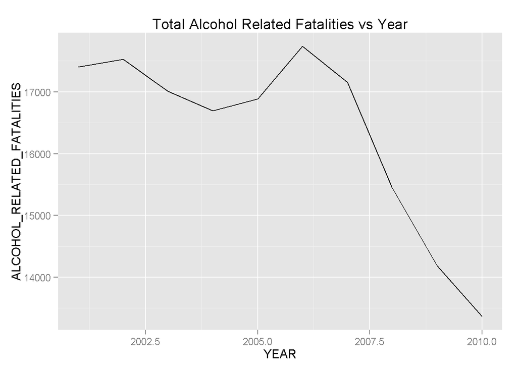

```
##
## > ggplot(figure_01_2, aes(x = YEAR, y = NON_ALCOHOL_RELATED)) +
## +     geom_line() + ggtitle("US NON_ALCOHOL_RELATED vs Year")
```

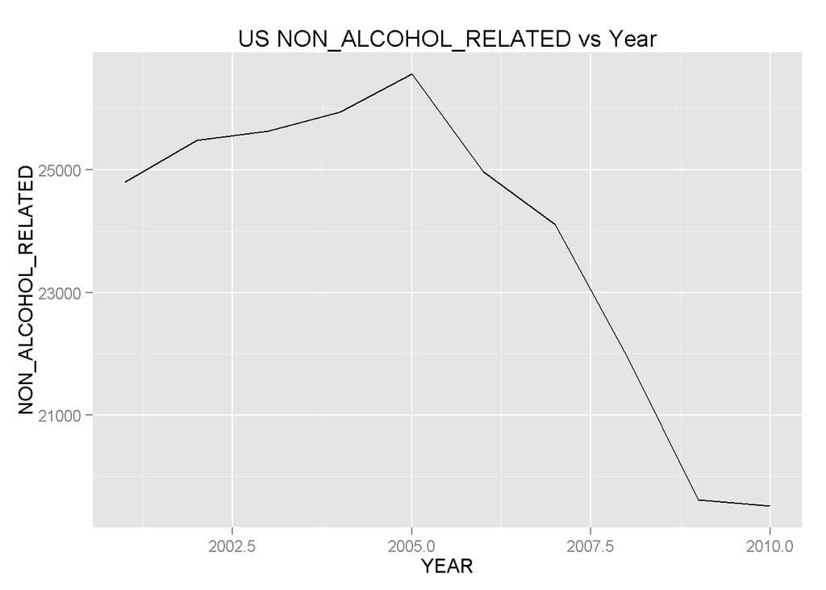

```
##
## > mdf <- melt(figure_01_2, id.vars = "YEAR", measure.vars = c("TOTAL_FATALITIES",
## +     "ALCOHOL_RELATED_FATALITIES", "NON_ALCOHOL_RELATED"))
##
## > ggplot(mdf, aes(x = YEAR, y = value, color = variable)) +
## +     geom_line() + ggtitle("Number of Alcohol Related v. Nonalcohol Related Highway Vehi ..." ... [TRUNCATED]
```

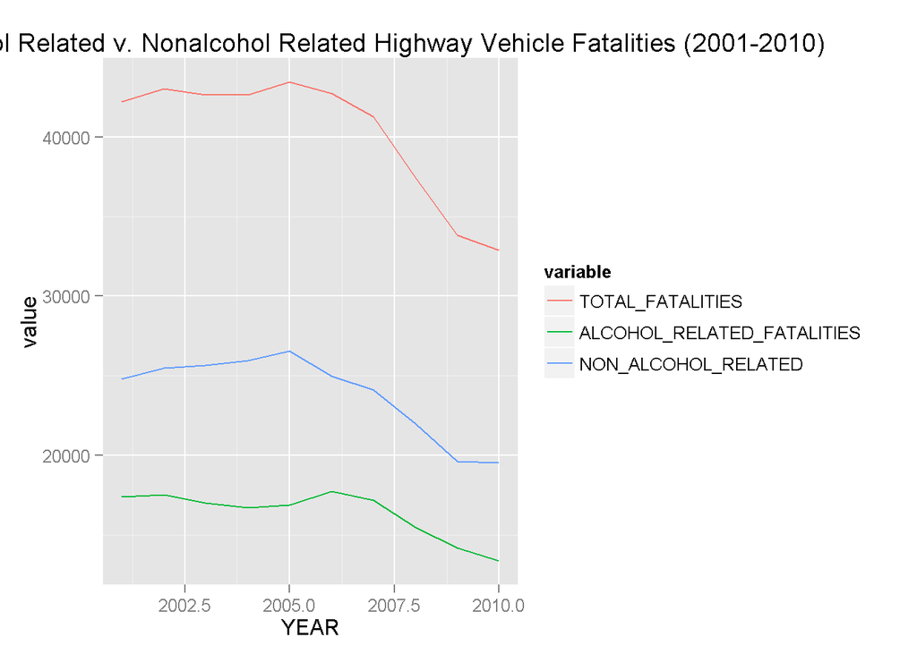

```
##
## > ggplot(mdf, aes(x = YEAR, y = value, fill = variable)) +
## +     geom_bar(stat = "identity") + ggtitle("Number of Alcohol Related v. Nonalcohol Relat ..." ... [TRUNCATED]
```

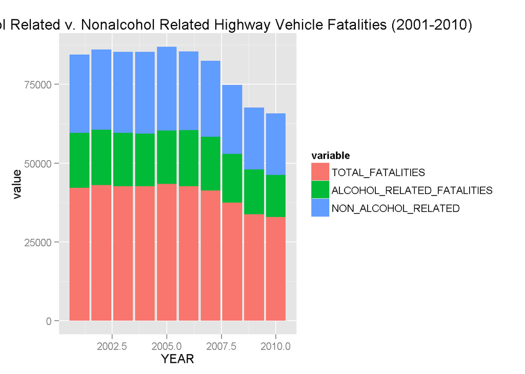

```
##
## > mdf2 <- melt(figure_02_2, id.vars = "YEAR", measure.vars = c("OCCUPANTS",
## +     "PEDESTRIANS", "PEDALCYCLISTS", "OTHERS_UNKNOWN"))
##
## > ggplot(mdf2, aes(x = YEAR, y = value, color = variable)) +
## +     geom_line() + ggtitle("Number of Highway vehicle Fatalities Involving Alcohol by P ..." ... [TRUNCATED]
```

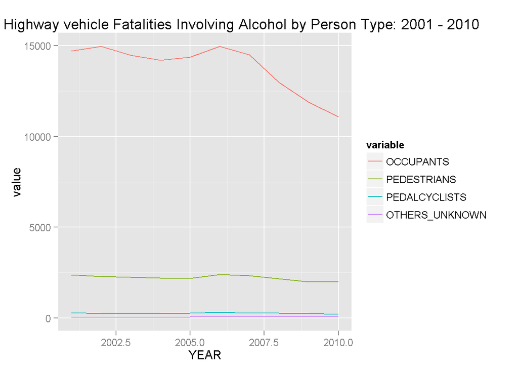

```
##
## > ggplot(mdf2, aes(x = YEAR, y = value, fill = variable)) +
## +     geom_bar(stat = "identity") + ggtitle("Number of Highway vehicle Fatalities Involvi ..." ... [TRUNCATED]
```

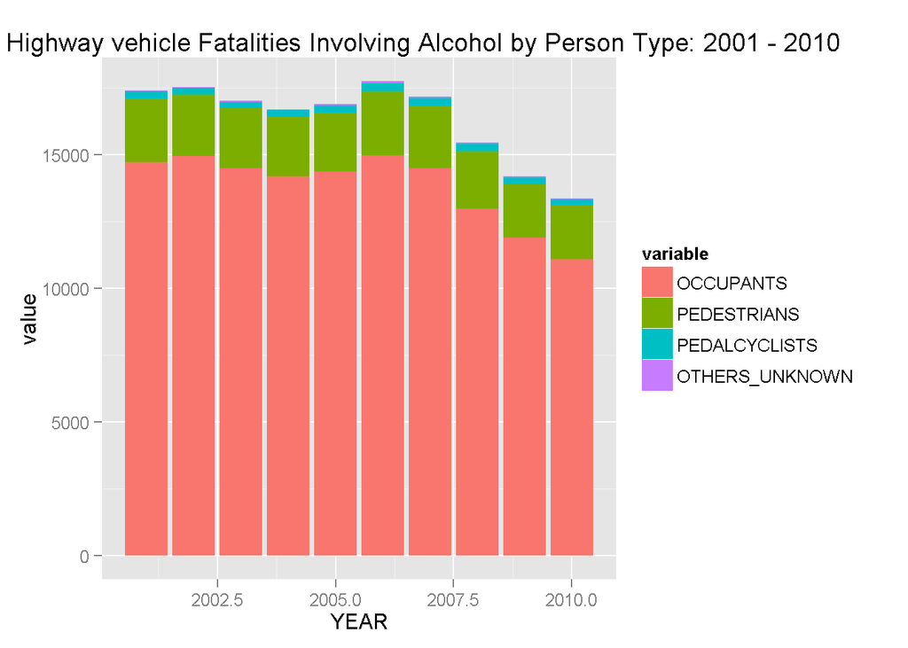

```
##
## > mdf3 <- melt(figure_03_2, id.vars = "YEAR", measure.vars = c("TOTAL_FATALITIES",
## +     "ALCOHOL_USE_FATALITIES", "WITHOUT_ALCOHOL_USE"))
##
## > ggplot(mdf3, aes(x = YEAR, y = value, color = variable)) +
## +     geom_line() + ggtitle("Alcohol Related vs. Nonalcohol Related Recreational Boating ..." ... [TRUNCATED]
```

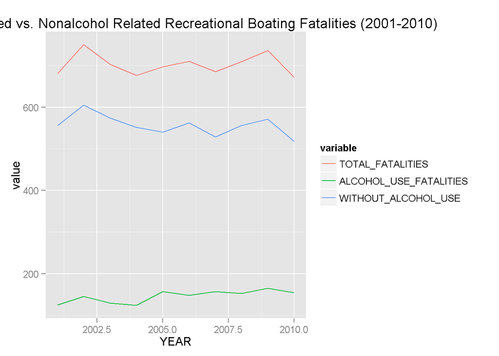

```
##
## > ggplot(figure_03_2, aes(x = YEAR, y = ALCOHOL_USE_FATALITIES)) +
## +     geom_bar(stat = "identity") + ggtitle("Alcohol Related Recreational Boating  ..." ... [TRUNCATED]
```

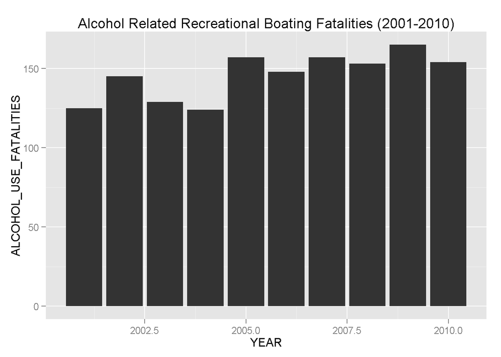

```
##
## > mdf4 <- melt(figure_03_2, id.vars = "YEAR", measure.vars = c("ALCOHOL_USE_FATALITIES",
## +     "WITHOUT_ALCOHOL_USE"))
##
## > ggplot(mdf4, aes(x = YEAR, y = value, fill = variable)) +
## +     geom_bar(stat = "identity") + ggtitle("Alcohol Related vs. Nonalcohol Related Recre ..." ... [TRUNCATED]
```

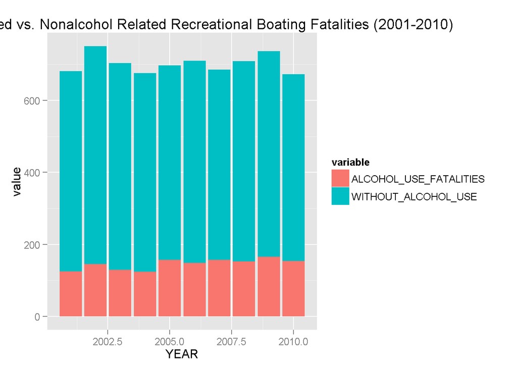

Datawrangling policy and Alcohol

```r
source("../02 Data Wrangling/Datawrangling.R", echo = TRUE)
```

```
##
## > require("jsonlite")
##
## > library("RCurl")
##
## > require(dplyr)
##
## > require(tidyr)
```

```
##
## > require("ggplot2")
##
## > library(extrafont)
##
## > library("reshape2")
##
## > setwd("C:/Users/willieman/Desktop/Skool/College Homework/_Senior Year/Spring 2015/CS 329e/DataVisualization/DV_FinalProject/0 Doc")
##
## > file_path <- "drinking_policies.csv"
##
## > df <- read.csv(file_path, stringsAsFactors = FALSE)
##
## > names(df) <- gsub("\\.+", "_", names(df))
##
## > str(df)
## 'data.frame':    194 obs. of  15 variables:
##  $ Country                       : chr  "Afghanistan" "Albania" "Algeria" "Andorra" ...
##  $ Sobriety_checkpoints          : chr  "No" "No" "Yes" "Yes" ...
##  $ General_population            : num  0 0.05 0.02 0.05 0.06 0 0.05 0.04 0.05 0.05 ...
##  $ Young_novice_drivers          : num  0 0.05 0.02 0.05 0.06 0 0.05 0.04 0 0.01 ...
##  $ commercial_drivers            : num  0 0.05 0.02 0.02 0.06 0 NA 0.04 0 0.01 ...
##  $ Community_service             : chr  "No" "No" "No" "Yes" ...
##  $ Detention_short_or_long_term  : chr  "Yes" "No" "Yes" "Yes" ...
##  $ Fines                         : chr  "Yes" "Yes" "Yes" "Yes" ...
##  $ Ignition_interlocks_alcolocks_: chr  "No" "No" "No" "No" ...
##  $ License_suspended_revoked     : chr  "No" "Yes" "Yes" "Yes" ...
##  $ Mandatory_treatment           : chr  "No" "No" "Yes" "Yes" ...
##  $ Penalty_points                : chr  "Yes" "No" "No" "No" ...
##  $ Vehicle_impounded             : chr  "No" "No" "Yes" "No" ...
##  $ Random_breath_testing_RBT_use : chr  "No" "Yes" "Yes" "Yes" ...
##  $ Patterns_of_drinking_score    : chr  NA "3- medium risky" "2- somewhat risky" "1- least risky" ...
##
## > measures <- c("General_population", "Young_novice_drivers",
## +     "commercial_drivers")
##
## > for (n in names(df)) {
## +     df[n] <- data.frame(lapply(df[n], gsub, pattern = "[^ -~]",
## +         replacement = ""))
## + }
```

[output cut: 46 more lines]

```
##  Patterns_of_drinking_score varchar2(4000),
##  General_population number(38,4),
##  Young_novice_drivers number(38,4),
##  commercial_drivers number(38,4)
##  );
## > drinking_policies <- data.frame(fromJSON(getURL(URLencode("129.152.144.84:5001/rest/native/?query=\"select * from drinking_policies\""),
## +     http .... [TRUNCATED]
##
## > abstainerslifetime <- data.frame(fromJSON(getURL(URLencode("129.152.144.84:5001/rest/native/?query=\"select * from ABSTAINERSLIFETIME\""),
## +     ht .... [TRUNCATED]
##
## > CONSUMPTION_OF_PURE_ALCOHOL <- data.frame(fromJSON(getURL(URLencode("129.152.144.84:5001/rest/native/?query=\"select * from CONSUMPTION_OF_PURE_ALCO .... [TRUNCATED]
##
## > fulljoin <- full_join(drinking_policies, abstainerslifetime,
## +     by = "COUNTRY")
```

```
##
## > fulljoin2 <- full_join(drinking_policies, CONSUMPTION_OF_PURE_ALCOHOL,
## +     by = "COUNTRY")
```

```
##
## > tbl_df(fulljoin2)
## Source: local data frame [196 x 20]
##
##                             COUNTRY SOBRIETY_CHECKPOINTS COMMUNITY_SERVICE
## 1                          Malaysia                  Yes                No
## 2                          Maldives                 null              null
## 3                              Mali                   No                No
## 4                             Malta                   No                No
## 5                  Marshall Islands                 null              null
## 6                        Mauritania                 null                No
## 7                         Mauritius                  Yes                No
## 8                            Mexico                  Yes                No
## 9  Micronesia (Federated States of)                  Yes               Yes
## 10                           Monaco                   No                No
## ..                              ...                  ...               ...
## Variables not shown: DETENTION_SHORT_OR_LONG_TERM (fctr), FINES (fctr),
##   IGNITION_INTERLOCKS_ALCOLOCKS_ (fctr), LICENSE_SUSPENDED_REVOKED (fctr),
##   MANDATORY_TREATMENT (fctr), PENALTY_POINTS (fctr), VEHICLE_IMPOUNDED
##   (fctr), RANDOM_BREATH_TESTING_RBT_USE (fctr), PATTERNS_OF_DRINKING_SCORE
##   (fctr), GENERAL_POPULATION (dbl), YOUNG_NOVICE_DRIVERS (dbl),
##   COMMERCIAL_DRIVERS (fctr), YEAR (int), BEER (int), WINE (int), SPIRITS
##   (int), OTHER_ALCOHOLIC_BEVERAGES (fctr)
##
## > fulljoin %>% select(COUNTRY, BOTHSEXES, PATTERNS_OF_DRINKING_SCORE,
## +     SOBRIETY_CHECKPOINTS) %>% filter(PATTERNS_OF_DRINKING_SCORE %in%
## +     c .... [TRUNCATED]
```

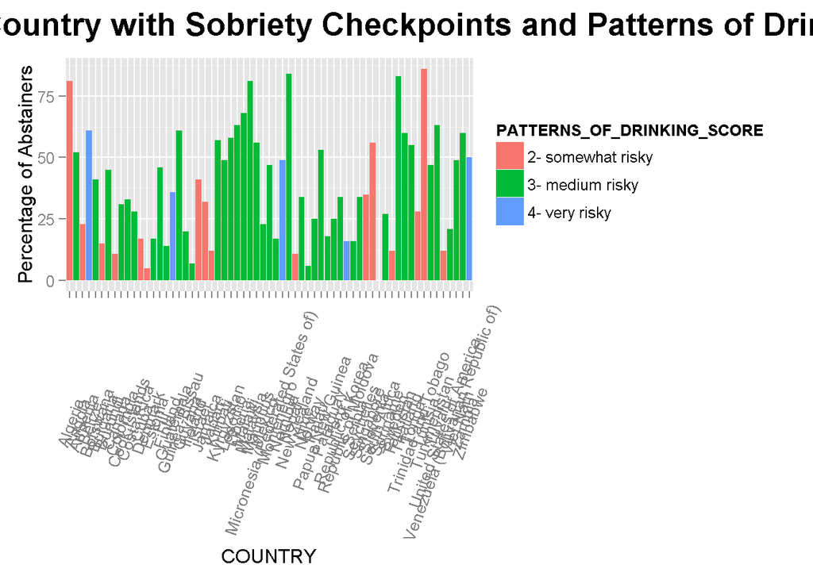

```
##
## > fulljoin2 %>% select(COUNTRY, BEER, PATTERNS_OF_DRINKING_SCORE,
## +     SOBRIETY_CHECKPOINTS) %>% filter(PATTERNS_OF_DRINKING_SCORE %in%
## +     c("2- ..." ... [TRUNCATED]
```

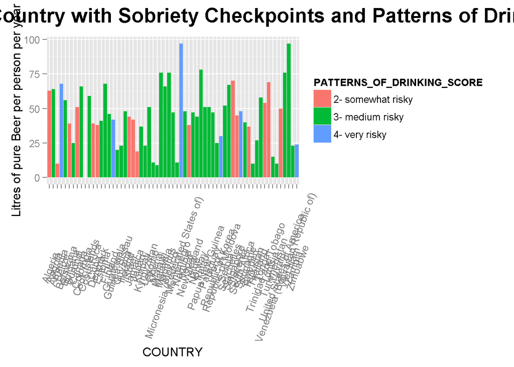

```
##
## > fulljoin2 %>% select(COUNTRY, BEER, RANDOM_BREATH_TESTING_RBT_USE) %>%
## +     filter(RANDOM_BREATH_TESTING_RBT_USE %in% c("Yes")) %>% ggplot(aes(x = .... [TRUNCATED]
```

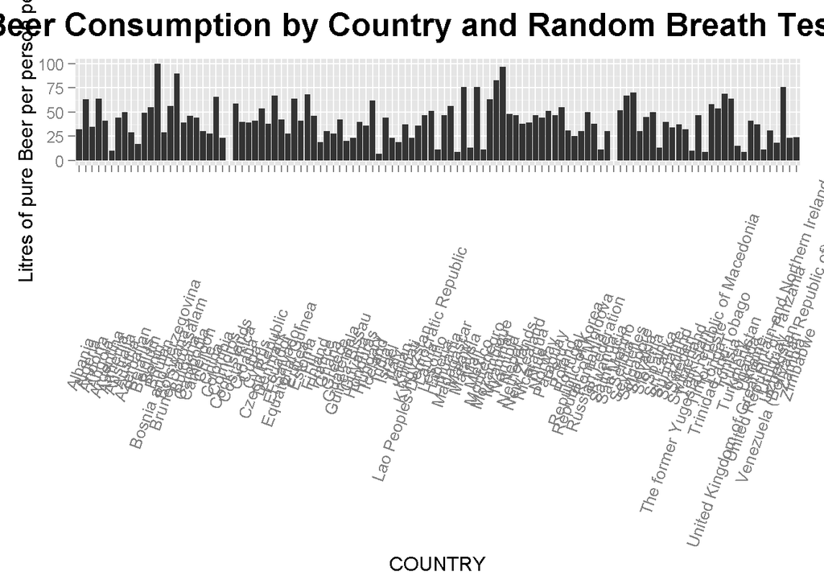

```
##
## > fulljoin2 %>% select(COUNTRY, BEER, RANDOM_BREATH_TESTING_RBT_USE) %>%
## +     filter(RANDOM_BREATH_TESTING_RBT_USE %in% c("No")) %>% ggplot(aes(x =  .... [TRUNCATED]
```

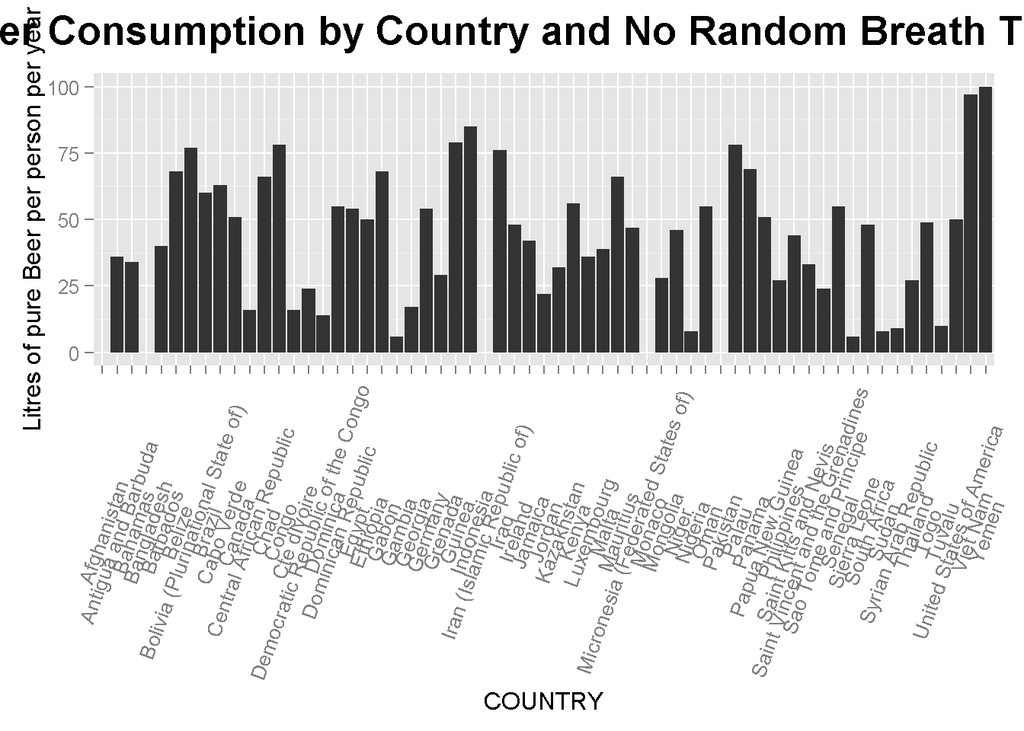

```
##
## > fulljoin2 %>% ggplot(aes(x = BEER, y = GENERAL_POPULATION)) +
## +     theme(plot.title = element_text(size = 20, face = "bold",
## +         vjust = 2) .... [TRUNCATED]
```

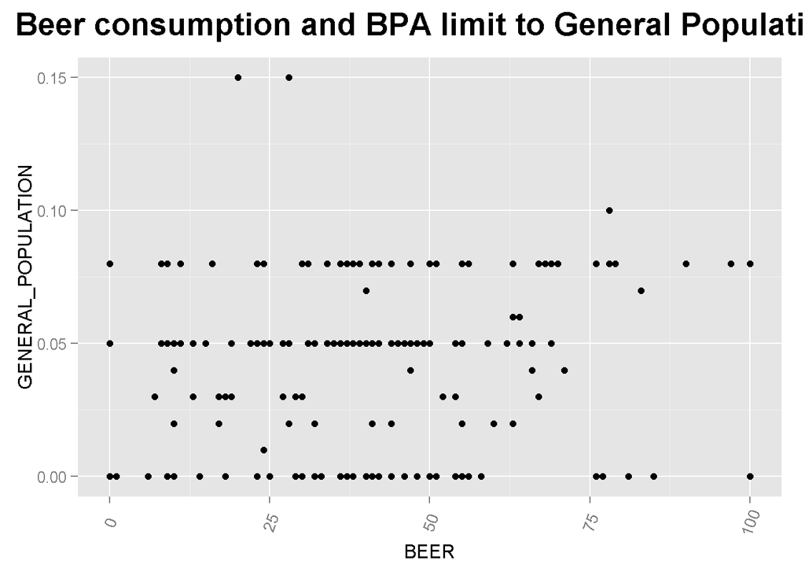

```
##
## > fulljoin2 %>% ggplot(aes(x = GENERAL_POPULATION, y = BEER)) +
## +     theme(plot.title = element_text(size = 20, face = "bold",
## +         vjust = 2) .... [TRUNCATED]
```

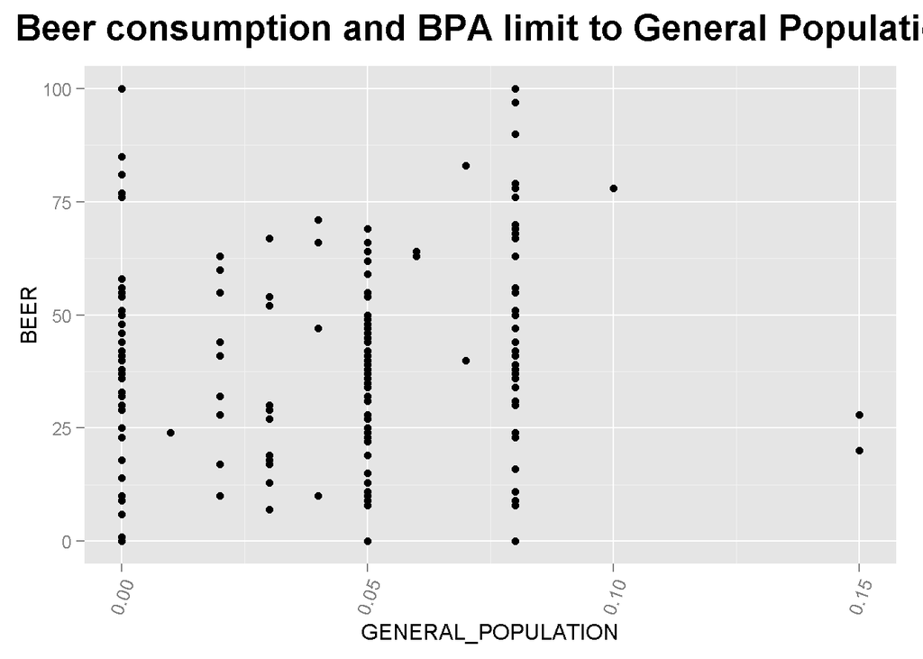

```
##
## > tbl_df(drinking_policies)
## Source: local data frame [194 x 15]
##
##                             COUNTRY SOBRIETY_CHECKPOINTS COMMUNITY_SERVICE
## 1                          Malaysia                  Yes                No
## 2                          Maldives                 null              null
## 3                              Mali                   No                No
## 4                             Malta                   No                No
## 5                  Marshall Islands                 null              null
## 6                        Mauritania                 null                No
## 7                         Mauritius                  Yes                No
## 8                            Mexico                  Yes                No
## 9  Micronesia (Federated States of)                  Yes               Yes
## 10                           Monaco                   No                No
## ..                              ...                  ...               ...
## Variables not shown: DETENTION_SHORT_OR_LONG_TERM (fctr), FINES (fctr),
##   IGNITION_INTERLOCKS_ALCOLOCKS_ (fctr), LICENSE_SUSPENDED_REVOKED (fctr),
##   MANDATORY_TREATMENT (fctr), PENALTY_POINTS (fctr), VEHICLE_IMPOUNDED
##   (fctr), RANDOM_BREATH_TESTING_RBT_USE (fctr), PATTERNS_OF_DRINKING_SCORE
##   (fctr), GENERAL_POPULATION (dbl), YOUNG_NOVICE_DRIVERS (dbl),
##   COMMERCIAL_DRIVERS (fctr)
```

Tableu Visualizations:

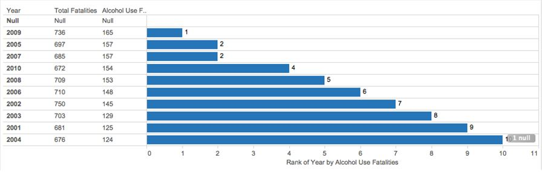

Based on year, ranked by Alcohol use fatalities from 1st to 10th highest.

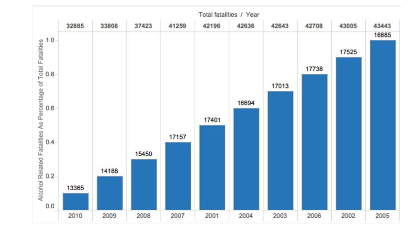

Rank from 0-1 Lowest to highest total fatalities based on year Adds alcohol related fatalities amount above

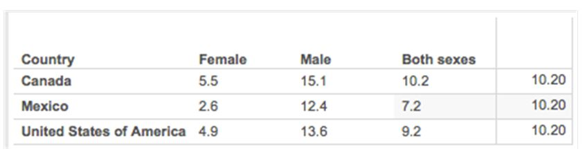

Used nth value Filtered by year 2008-2010, and filtered by just north american countries Canada has both total consumption between men and women

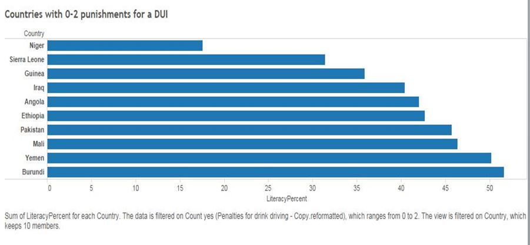